# DAB501 - Final Project

**9. Name the top 5 video games with highest total sales and compare the values.**

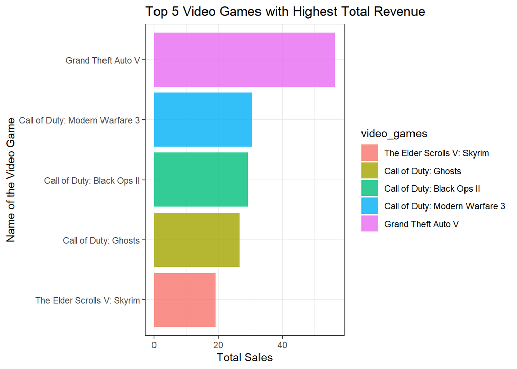

```r
vg_clean %>% group_by(Name) %>%
  summarise(gsales_by_game = sum(Global_Sales)) %>%
  arrange(desc(gsales_by_game)) %>%
  slice(1:5) %>%
  mutate(video_games = fct_reorder(Name, gsales_by_game)) %>%
  ggplot(aes(y=video_games, x=gsales_by_game, fill=video_games)) +
  geom_col(stat="identity", alpha=.8, width=0.9) +
  theme_bw() +
  labs(title = "Top 5 Video Games with Highest Total Revenue", x="Total Sales", y="Name of the Video Game")
```

The graph shows the top 5 Video Games companies which generates highest total sales for the given year. The first name here is - Grand theft Auto v with revenue around 56 millions. The difference ij revenue of Call of Duty series is almost equal with a little variation. The 5th game is The Elder Scroll V Skyrim with 19 million revenue.

**10. Compare the total sales generated by top 5 development companies.**

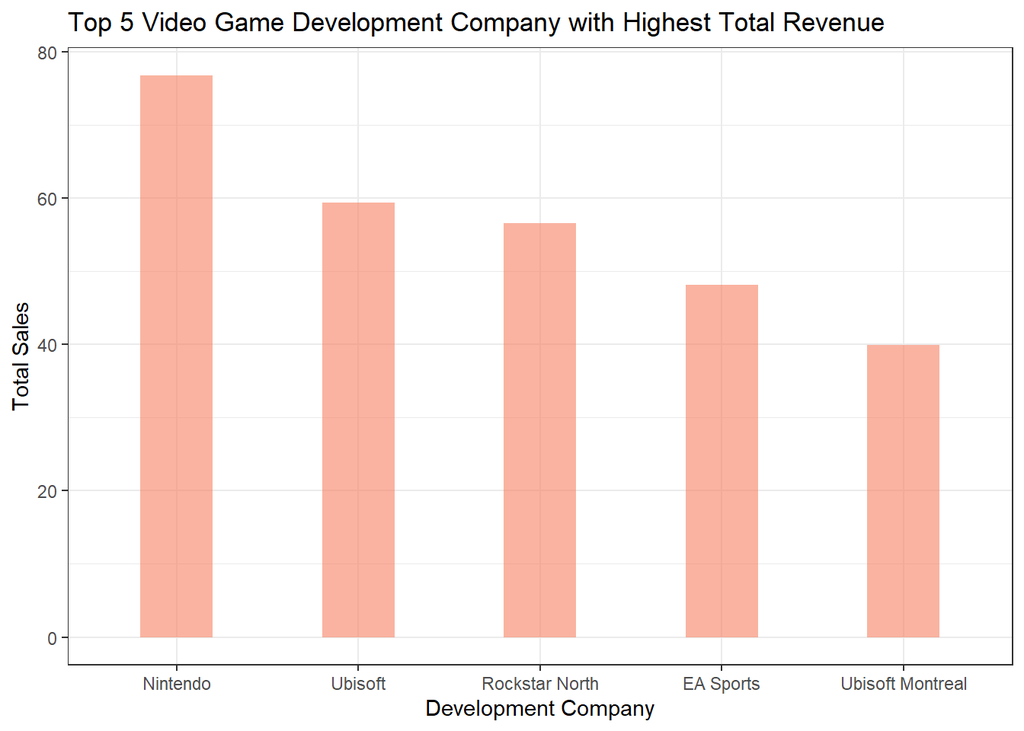

```r
vg_clean %>% group_by(Developer) %>%
  summarise(gsales_by_dev = sum(Global_Sales)) %>%
  arrange(desc(gsales_by_dev)) %>%
  slice(1:5) %>%
  mutate(name = fct_reorder(Developer, desc(gsales_by_dev))) %>%
  ggplot(aes(x=name, y=gsales_by_dev)) +
  geom_col(stat="identity", fill="#f68060", alpha=.6, width=.4) +
  theme_bw() +
  labs(title = "Top 5 Video Game Development Company with Highest Total Revenue", x="Development Company", y="Total Sales")
```

The graph shows the top 5 development companies with highest total revenue. The topmost company is Nintendo with total sales around 75 millions, followed by Ubisoft, Rockstar, EA Sports and Ubisoft Montreal.

**11. Compare the total revenue of top 5 publishers.**

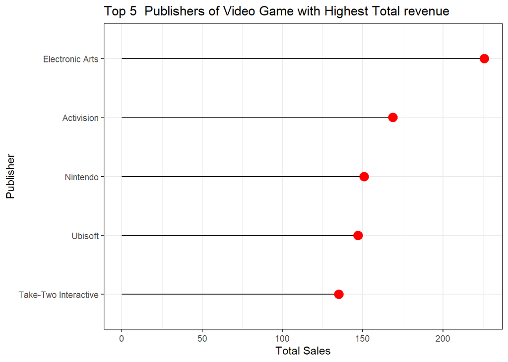

```r
vg_clean %>% group_by(Publisher) %>%
  summarise(gsales_by_pbl = sum(Global_Sales)) %>%
  arrange(desc(gsales_by_pbl)) %>%
  slice(1:5) %>%
  mutate(name = fct_reorder(Publisher, gsales_by_pbl)) %>%
  ggplot(aes(x=name, y=gsales_by_pbl)) +
  geom_segment( aes(xend=name, yend=0)) +
    geom_point( size=4, color="red") +
    coord_flip() +
    theme_bw() +
  labs(title = "Top 5  Publishers of Video Game with Highest Total revenue", x="Publisher", y="Total Sales")
```

The above plot compares the top 5 publishers of the video games which generates highest total revenue in the given year. It can be clearly seen that Electronics Arts is at the top with 225 millions revenue approximately, followed by Activision, Nintendo, Ubisoft and Take-Two Interactive with total revenues between 175 and 130 millions.